# lmerSeq: An R package for fitting linear mixed models to RNA-Seq data

Brian Vestal, Elizabeth Wynn, & Camille Moore

2022-07-20

As the cost of sequencing decreases, the complexity and size of RNA-Seq experiments are rapidly growing. In particular, paired, longitudinal and other correlated study designs are becoming commonplace. However, the tools available to correctly analyze these more complex study designs have been limited. In Vestal et al. 2019, we developed a Bayesian hierarchical negative binomial mixed model framework (called MCMSeq) that could directly handle count the data from RNA-Seq experiments with repeated measures. Though MCMSeq performed best in terms of achieving good sensitivity while maintaining nominal type 1 error and false discovery rates (FDR) among the methods explored in that paper, the only other alternative that came close to matching its performance was to transform the counts, and then fit regular linear mixed models. In this R package, entitled lmerSeq, we provide some convenient wrapper functions to fit these linear mixed models (using the lmerTest R package) and obtain results tables in a similar spirit to the `edgeR` or `DESeq2` analysis pipelines. In the following vignette, we provide an example analysis on simulated RNA-Seq data to show how to fit the models, summarize the results for a single coefficient, and then test a linear contrast of coefficients.

# 1 Model Specification

To model the observed RNA-Seq count data, we first transform the counts using a normalizing transformation such as the variance stabilizing transformation offered in the `vst` function in `DESeq2`. We model the transformed data using a linear mixed model. To account for correlation, we allow a random effects to be included in the model. Let $Y_{gij}$ be the transformed value of the expression of gene $g$ from subject $i$ at time point or observation $j$, then
$$\begin{eqnarray}
\label{eqn:glmm}
Y_{gij} &\sim& \mathcal{N}(\mu_{gij}, \sigma_g^2) \\
\mu_{gij} &=& X_{ij}\boldsymbol{\beta_g} + \mathbf{Z}_{ij}\mathbf{b}_{gi} \\
{b_{gi}} &\sim& \mathcal{MVN}(\mathbf{0}, \boldsymbol{\Sigma}_{gb})
\end{eqnarray}$$
where $\mu_{gij}$ is the mean transformed expression of gene $g$ in subject $i$ at observation $j$ and $\sigma_g^2$ is the variance parameter for gene $g$. $\boldsymbol{\beta_g}$ is a $p$ by 1 vector of fixed effect regression coefficients for gene $g$, $X_{ij}$ is a row vector of fixed effects covariates for subject $i$ at observation $j$, and $\mathbf{b}_{gi}$ is a vector of random intercept for gene $g$ and subject $i$. We assume that for each gene $g$, the subject-specific random effects have a multivariate normal distribution with mean $\mathbf{0}$ and variance-covariance matrix $\boldsymbol{\Sigma}_{bg}$.

# 2 Overview of Functions in the lmerSeq Package

The three main functions in the `lmerSeq` package are `lmerSeq.fit`, which is used to fit lmerSeq models, `lmerSeq.summary`, which is used to summarize individual regression coefficients, and `lmerSeq.contrast`, which is used to summarize individual linear contrasts coefficients. Each function has several required arguments and options which are described below.

## 2.1 lmerSeq.fit

### 2.1.1 *Required Arguments*

[output not shown]

### 2.1.2 *Aditional Arguments*

| Option | Description | Default |
| --- | --- | --- |
| gene_names | An optional character vector of gene names (length G). If unspecified, row names from the expression matrix will be used. | NULL |
| REML | Should the models be fit with REML or regular ML? | TRUE |
| parallel | If on Mac or Linux, use forking (via mclapply) to parallelize fits. | FALSE |
| cores | Number of cores to use if using parallelizing fits. | 2 |

## 2.2 lmerSeq.summary

### 2.2.1 *Required Arguments*

| Argument | Description |
| --- | --- |
| lmerSeq_results | Results object from running lmerSeq.fit. |
| coefficient | Character string or numeric indicator of which coefficient to summarize. |

### 2.2.2 *Aditional Arguments*

| Option | Description | Default |
| --- | --- | --- |
| p_adj_method | Method for adjusting for multiple comparisons (default is Benjamini-Hochberg). | “BH” |
| ddf | Method for computing degrees of freedom and t-statistics. Options are “Satterthwaite” and “Kenward-Roger”. | “Satterthwaite” |
| sort_results | Should the results table be sorted by adjusted p-value? | TRUE |

## 2.3 lmerSeq.contrast

### 2.3.1 *Required Arguments*

[output not shown]

### 2.3.2 *Aditional Arguments*

| Option | Description | Default |
| --- | --- | --- |
| p_adj_method | Method for adjusting for multiple comparisons (default is Benjamini-Hochberg). | “BH” |
| ddf | Method for computing degrees of freedom and t-statistics. Options are “Satterthwaite” and “Kenward-Roger”. | “Satterthwaite” |
| sort_results | Should the results table be sorted by adjusted p-value? | TRUE |

# 3 An Example lmerSeq Analysis

```r
# Load the library
library(lmerSeq)
# Load the data
data("expr_example")
names(expr_example)
```

```
#> [1] "vst_expr"         "sample_meta_data"
```

```r
# sample_meta_data has information about the the study design
# each row is a sample and corresponds to a column
# in the expression matrix (vst_expr)
sample_meta_data <- expr_example$sample_meta_data
sample_meta_data
```

```
#>    group time ids
#> 1      0    0   1
#> 2      0    0   2
#> 3      0    0   3
#> 4      0    0   4
#> 5      0    0   5
#> 6      1    0   6
#> 7      1    0   7
#> 8      1    0   8
#> 9      1    0   9
#> 10     1    0  10
#> 11     0    1   1
#> 12     0    1   2
#> 13     0    1   3
#> 14     0    1   4
#> 15     0    1   5
#> 16     1    1   6
#> 17     1    1   7
#> 18     1    1   8
#> 19     1    1   9
#> 20     1    1  10
```

```r
# The expression matrix (vst_expr) has the same number of columns as
# rows in metadata.  The columns of the counts matrix
# are in the same order as the rows of the metadata.
vst_expr <- expr_example$vst_expr[1:500,]
head(vst_expr)
```

```
#>                1         2         3         4         5         6         7
#> gene_1  9.718066 11.287075 10.424919 10.054660  9.930321  9.960479  9.838390
#> gene_2  7.695786  7.634494  7.057765  7.423232  9.826636  7.173738  8.472930
#> gene_3  9.068397  8.728583  8.587318  8.078244  8.300322  8.121162  8.489013
#> gene_4 10.201287  9.499400 12.000497 11.394558 14.037695 15.662026 11.168083
#> gene_5  5.420767  4.834965  7.001491  5.318385  5.419777  5.197268  6.020709
#> gene_6  5.768313  6.306045  6.286288  5.551270  5.766971  6.749169  5.857482
#>                8         9        10        11        12        13        14
#> gene_1 10.365072 10.513962  9.842168  9.629550 11.696100 10.796711 10.533148
#> gene_2  8.701982  7.572121  7.070354  6.336361  6.326748  8.889667  6.184038
#> gene_3  8.732537  8.156784  8.390283  8.785989  8.622098  9.172592  7.896454
#> gene_4 12.631002 13.858078 12.538125 10.327079  9.904219 13.408116 10.548494
#> gene_5  5.197436  6.162586  6.068089  4.960007  5.315978  6.181032  5.731777
#> gene_6  5.912008  5.994762  6.225875  6.517208  6.307201  6.202680  5.856596
#>               15        16        17        18        19        20
#> gene_1 11.942505  9.353982  8.564307  8.529466  9.379239  8.922996
#> gene_2  6.996296  7.079122  7.789405  7.745766  7.011949  8.454777
#> gene_3  8.444398  8.680169  8.381761  8.623554  8.382786  8.348355
#> gene_4 13.350749 13.445610 12.198269 12.197086 12.095550 12.076660
#> gene_5  5.503720  5.197166  5.629334  5.464986  4.538137  5.970139
#> gene_6  6.340748  6.181377  6.120376  6.094641  5.505685  6.270948
```

The goal of our analysis will be to compare changes over time between the control and treatment groups. For this example, the model will use a random intercept and no other random effects. Thus, we will fit the following model to the data:

$$\begin{eqnarray}
\label{eq:sim_data}
Y_{gij} &\sim& \mathcal{N}(\mu_{gij}, \sigma_g^2) \\
\mu_{gij} &=& \beta_{g0} + \beta_{g1} I_{T_i} + \beta_{g2} I_{F_{ij}} + \beta_{g3}I_{T_i} I_{F_{ij}} + b_{gi} \nonumber \\
b_{gi} &\sim& \mathcal{N}(0, \sigma_{gb}^2) \nonumber
\end{eqnarray}$$
where $I_{T_i}$ is an indicator function that equals 1 if subject $i$ is in the treatment group, $I_{F_{ij}}$ is a similar indicator for if observation $j$ is the follow-up, and $b_{gi}$ is the random intercept for gene $g$ and subject $i$.

## 3.1 Fitting the Model

To fit the model, we use the lmerSeq.fit function. The `expr_mat` argument takes a data frame or matrix of transformed RNA-seq counts, the columns of which must be in the same order as the rows of `sample_data` data frame, which contains metadata on each sample. Fixed and random effects are passed to the `form` argument using the syntax of the `lme4` package and must be included in the `sample_data` data frame. By default, the lmerSeq.fit will use rownames of the counts matrix to identify genes. If you would like to use a different set of gene names, you can supply a character vector of names in the same order as the rows of the counts matrix to the gene_names option. If you are using Mac or Linux and would like to use use forking (via `mclapply`) to parallelize fits, the `parrallel` argument should be set to `TRUE` and the number of cores to be used should be passed to the `cores` argument. Finally, if you would like to use regular maximum likelihood (ML) instead of restricted maximum likelihood (REML), set the `REML` argument to `FALSE`.

```r
 ##  Fit the Model
 fit.lmerSeq <- lmerSeq.fit(form = ~ group * time + (1|ids),
                            expr_mat = vst_expr,
                            sample_data = sample_meta_data,
                            REML = T)
# Look at lmerSeq.fit object
class(fit.lmerSeq)
```

```
#> [1] "list"
```

```r
#Length is number of genes
length(fit.lmerSeq)
```

```
#> [1] 500
```

```r
# Names for individual element
names(fit.lmerSeq[[1]])
```

```
#> [1] "fit"  "gene"
```

The resulting lmerSeq object is a list with elements for every gene in the expression matrix. Each gene element contains two items. The first item, `fit` is an object of class `lmerModLmerTest` (see `lmerTest` package) which contains information concerning the model fit. The item `gene` contains the genename (or rowname from the expression matrix if gene names were not provided).

## 3.2 Summarizing Results

Model coefficients can be more easily summarized with the `lmSeq.summary` function, which calculates and tabulates adjusted p-values, as well as other results. The coefficient of interest can be passed to the function either as a numeric indicator or character string. In calculating adjusted p-values, you can choose between various adjustment methods (see `p.adjust.methods)` and two degree of freedom methods (Satterthwaite or Kenward-Roger). The resulting table can also be sorted by adjusted p-value by setting the `sort_results` option to `TRUE`.

```r
 ##  Summarize the group and time coefficients
 model_sum_time <- lmerSeq.summary(lmerSeq_results = fit.lmerSeq,
                              coefficient = 3,
                              p_adj_method = 'BH',
                              ddf = 'Satterthwaite',
                              sort_results = F)
 model_sum_group <- lmerSeq.summary(lmerSeq_results = fit.lmerSeq,
                              coefficient = "group",
                              p_adj_method = 'BH',
                              ddf = 'Satterthwaite',
                              sort_results = T)
#Look at summary object
names(model_sum_time)
```

```
#> [1] "coefficient"   "summary_table" "singular_fits" "ddf"
#> [5] "p_adj_method"
```

```r
head(model_sum_time$summary_table)
```

```
#>     gene    Estimate Std..Error df    t.value  p_val_raw p_val_adj
#> 1 gene_1  0.63659436  0.2915141  8  2.1837514 0.06050758 0.9313845
#> 2 gene_2          NA         NA NA         NA         NA        NA
#> 3 gene_3  0.03173314  0.1427935  8  0.2222310 0.82970244 0.9950362
#> 4 gene_4  0.08104382  0.4960346  8  0.1633834 0.87426859 0.9950362
#> 5 gene_5 -0.06057395  0.2944411  8 -0.2057252 0.84214422 0.9950362
#> 6 gene_6  0.30910901  0.1669197  8  1.8518424 0.10119010 0.9949722
```

Along with information about the function call, the resulting summary object contains a list of genes whose corresponding models were singular, and a summary table. For each gene, the summary table displays the model estimate, standard error, degree of freedom, t-value, and raw and adjusted p-values. Values for genes with singular models or models that did not converge are marked `NA`.

## 3.3 Summarizing individual linear contrasts

We are also interested in the following contrasts or linear combinations of regression parameters:

- $\beta_{g1} + \beta_{g3} = 0$ tests for differences in expression between the treatment and the control group at follow-up
- $\beta_{g1}=0 \text{ or }\beta_{g2} = 0 \text{ or }\beta_{g3} = 0$ simultaneously tests all of the coefficients

The `lmerSeq.contrast` function allows users to specify custom contrasts that are either one dimensional or multi-dimensional. If the contrast matrix has only one row, a t-test is executed while if the contrast matrix has more than 1 row, an F-test is used. The contrast matrix must have the same number of columns as fixed effects and if more than one row is supplied, each row should correspond to a contrast to be simultaneously tested with the other supplied contrasts.

The function calculates adjusted p-values according to the adjustment method you choose (see `p.adjust.methods)`. You can also specify the method for the degree of freedom calculation (Satterthwaite or Kenward-Roger). The resulting contrast summary table can also be sorted by adjusted p-value by setting the `sort_results` option to `TRUE`.

The fixed effects in the contrast matrix must be in the same order specified by the model formula. If you are unsure of the ordering, you can look at the design matrix for any gene model fit in the lmerSeq fit object. To see the design matrix:

```r
# Look at the fixed effects design matrix to develop the contrast_mat
model.matrix(fit.lmerSeq[[1]]$fit)
```

```
#>    (Intercept) group time group:time
#> 1            1     0    0          0
#> 2            1     0    0          0
#> 3            1     0    0          0
#> 4            1     0    0          0
#> 5            1     0    0          0
#> 6            1     1    0          0
#> 7            1     1    0          0
#> 8            1     1    0          0
#> 9            1     1    0          0
#> 10           1     1    0          0
#> 11           1     0    1          0
#> 12           1     0    1          0
#> 13           1     0    1          0
#> 14           1     0    1          0
#> 15           1     0    1          0
#> 16           1     1    1          1
#> 17           1     1    1          1
#> 18           1     1    1          1
#> 19           1     1    1          1
#> 20           1     1    1          1
#> attr(,"assign")
#> [1] 0 1 2 3
#> attr(,"msgScaleX")
#> character(0)
```

```r
 ##  Contrast 1: t-test for difference in expression between groups at follow-up
 cont_mat1 <- rbind(c(0, 1, 0, 1))
 contrast_summary1 <- lmerSeq.contrast(lmerSeq_results = fit.lmerSeq,
                                       contrast_mat = cont_mat1,
                                       p_adj_method = 'BH',
                                       ddf = 'Satterthwaite',
                                       sort_results = T)
#Look at summary object
names(contrast_summary1)
```

```
#> [1] "contrast_mat"  "summary_table" "singular_fits" "ddf"
#> [5] "p_adj_method"
```

```r
head(contrast_summary1$summary_table)
```

```
#>       gene   Estimate Std..Error       df    t.value     lower      upper
#> 1  gene_79 -1.5133551 0.12985850 14.66841 -11.653878 -1.790688 -1.2360223
#> 2 gene_213  1.4914738 0.11694966 12.47311  12.753126  1.237730  1.7452174
#> 3 gene_282 -0.9888268 0.09266452 13.39747 -10.671039 -1.188414 -0.7892393
#> 4  gene_18 -1.1798761 0.09767387 10.97202 -12.079752 -1.394922 -0.9648305
#> 5 gene_306  1.5584425 0.13039113 11.03684  11.952059  1.271570  1.8453146
#> 6 gene_227 -1.2374272 0.14611763 13.19691  -8.468706 -1.552617 -0.9222374
#>      p_val_raw    p_val_adj
#> 1 8.226902e-09 3.443222e-06
#> 2 1.597783e-08 3.443222e-06
#> 3 6.336917e-08 9.104038e-06
#> 4 1.114548e-07 1.010998e-05
#> 5 1.172852e-07 1.010998e-05
#> 6 1.071699e-06 7.698373e-05
```

```r
 ##  Contrast 2: F-test for for all coefficients
 cont_mat2 <- rbind(c(0, 1, 0, 0),
                    c(0, 0, 1, 0),
                    c(0, 0, 0, 1))
 contrast_summary2 <- lmerSeq.contrast(lmerSeq_results = fit.lmerSeq,
                                       contrast_mat = cont_mat2,
                                       p_adj_method = 'BH',
                                       ddf = 'Satterthwaite',
                                       sort_results = T)
#Look at summary object
names(contrast_summary1)
```

```
#> [1] "contrast_mat"  "summary_table" "singular_fits" "ddf"
#> [5] "p_adj_method"
```

```r
head(contrast_summary2$summary_table)
```

```
#>       gene   Sum.Sq  Mean.Sq NumDF     DenDF   F.value    p_val_raw
#> 1  gene_18 3.595652 1.198551     3 11.687071 155.55479 1.090361e-09
#> 2 gene_306 6.885861 2.295287     3 11.634709 163.93176 8.684031e-10
#> 3 gene_213 5.959866 1.986622     3 10.340267 124.07962 2.118797e-08
#> 4 gene_282 5.045258 1.681753     3  9.918288 140.08266 2.030633e-08
#> 5 gene_335 3.727131 1.242377     3 11.466385  74.38477 8.578441e-08
#> 6  gene_79 7.763287 2.587762     3  9.920562  87.85174 1.903840e-07
#>      p_val_adj
#> 1 2.349727e-07
#> 2 2.349727e-07
#> 3 2.283004e-06
#> 4 2.283004e-06
#> 5 7.394616e-06
#> 6 1.367591e-05
```

Like with the `lmerSeq.summary` function, the object produced by the `lmerSeq.contrast` function contains information about the function call, a list of genes whose corresponding models were singular, and a summary table. For one dimensional contrasts, the summary table displays the contrast estimate and 95% confidence limits, standard error, degrees of freedom, t-value, and raw and adjusted p-values. For multi-contrasts tests, the summary table contains the sum of squares and mean sum of squares, numerator and denominator degrees of freedom, the F-statistic, and raw and adjusted p-values. In both tables values for genes with singular models or models that did not converge are marked `NA`.

## 3.4 Evaluating Model Assumptions

Evaluating the goodness of fit and modeling assumptions across thousands of genes is challenging. We suggest considering the number of singular fits, as well as violations of normality and homogeneity of variance assumptions for residuals.

### 3.4.1 Singular Model Fits

Models are singular if one or more random effect variance component is estimated to be 0. lmerSeq automatically returns `NA` values for singular models in results tables. However, if a large proportion of model fits are singular, it may suggest that the model was too complex for the available data and simplification by removing some of the fixed and/or random effects terms may be warranted. The number of singular fits can be found as follows:

```r
# Number of singular fits
length(contrast_summary2$singular_fits)
```

```
#> [1] 69
```

```r
# Proportion of singular fits
length(contrast_summary2$singular_fits)/nrow(contrast_summary2$summary_table)
```

```
#> [1] 0.138
```

### 3.4.2 Diagnositic Statistics for Residuals

Since `lmerSeq.fit` returns the model fit for each gene, any R package or function for evaluating linear mixed model fits for merMod objects, including the performance and DHARMa R packages, can be used to test model assumptions. In addition, functions like ks.test and leveneTest from the car package are also be useful for quickly evaluating normality of residuals and equality of variance assumptions.

The ks.test function in the stats package performs the Kolmogorov-Smirnov test, which can be used to assess deviations from normality and can be applied to lmerSeq model fits as follows:

```r
# KS test for normality
ks <- lapply(fit.lmerSeq, function(x) ks.test(residuals(x$fit, scale=T), 'pnorm')$p.value)
table(unlist(ks) < 0.05)
```

```
#>
#> FALSE
#>   500
```

```r
table(p.adjust(unlist(ks), method='BH')<0.05)
```

```
#>
#> FALSE
#>   500
```

The leveneTest function in the car package can be used to test for heteroskedasticity between grouping variables. This test can be performed across all the model fits using an lapply statement as follows:

```r
library(car)
# Levine's test for heteroskedasticity
sample_meta_data$group_time <- factor(paste0('g', sample_meta_data$group, "_t", sample_meta_data$time))
lt <- lapply(fit.lmerSeq, function(x) leveneTest(residuals(x$fit, scale=T)~factor(sample_meta_data$group_time))$`Pr(>F)`[1])
table(unlist(lt) < 0.05)
```

```
#>
#> FALSE  TRUE
#>   499     1
```

```r
table(p.adjust(unlist(lt), method='BH')<0.05)
```

```
#>
#> FALSE
#>   500
```

Given the large number of genes, it is likely that some will have unadjusted p-values less than 0.05 by chance alone. Therefore, we suggest visually inspecting quantile-quantile and residual plots for differentially expressed genes with significant Kolmogorov-Smirnov or Levene p-values.

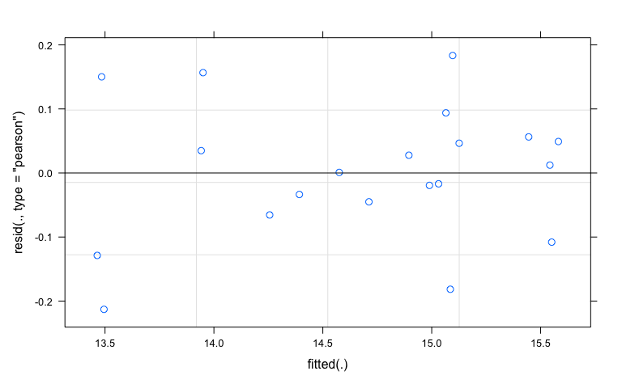

```r
# Plot Residuals
for(i in which(lt < 0.05)){
  print(plot(fit.lmerSeq[[i]]$fit))}
```

More in depth testing and exploration can also be performed using the DHARMa package.

```r
# Explore model fit using DHARMa
library(DHARMa)
```

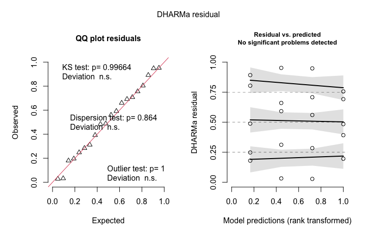

```r
for(i in which(lt < 0.05)){
simulationOutput <- simulateResiduals(fit.lmerSeq[[which(lt < 0.05)]]$fit)
plot(simulationOutput)
}
```